# Exam 1

## Exam 1

#### Metainformation

1. | Tag | Value |
   | --- | --- |
   | `file` | Inferential_Statistics_vufsw-multiple_linear_regression-2088-nl_vufsw-multiple_linear_regression-2088-nl |
   | `name` | vufsw-multiple linear regression-2088-nl |
   | `section` | inferential statistics/regression/multiple linear regression |
   | `type` | schoice |
   | `solution` | FALSE, FALSE, TRUE, FALSE |
   | `ID` | ef984 |
   | `Type` | interpreting output |
   | `Program` | NA |
   | `Language` | Dutch |
   | `Level` | statistical reasoning |

#### Question

   We analyseren data die afkomstig zijn van scholieren van het voortgezet onderwijs uit de Jongeren & Cultuurdata (Ganzeboom & Nagel, 1998-2002). Voor dit databestand zijn ruim 3000 jongeren ondervraagd in de leeftijd van grofweg 14 tot 17 jaar. In onderstaande regressieanalyse is de participatie in populaire cultuur de afhankelijke variabele (pjcul: 0-100, van weinig naar veel participatie) en zijn de onafhankelijke variabelen moeders cultuurparticipatie (pmcul: 0-1, van minst naar meest cultureel actief) en schoolniveau (in dummy’s, referentiegroep = vmbo-b). Er zijn in model 3 bovendien interacties toegevoegd tussen moeders cultuurparticipatie en schoolniveau.

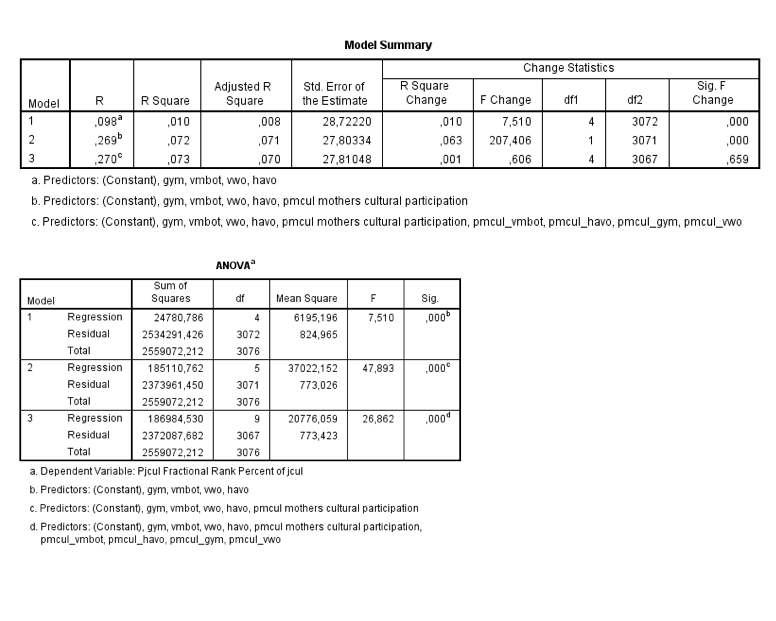

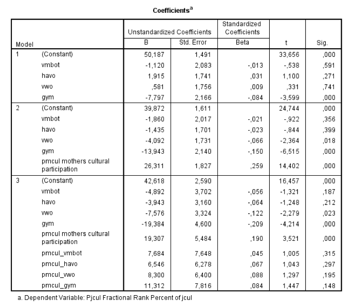

   Welke conclusie kun je uit model 2 trekken over de populatie scholieren?  
   1: Vmbo-b leerlingen doen meer aan populaire cultuur dan vwo leerlingen met een vergelijkbaar cultureel actieve moeder  
   2: Voor vwo leerlingen geldt dat naarmate de moeder meer aan cultuur doet, zij meer aan populaire cultuur doen.
   1. **FALSE:** Alleen 1 is waar
   2. **FALSE:** Alleen 2 is waar
   3. **TRUE:** Zowel 1 als 2 zijn waar
   4. **FALSE:** 1 en 2 zijn beide onwaar
   1. False
   2. False
   3. True
   4. False